# Overview

Phenology is the timing of life history events. Important phenological events for plants involve the growth of leaves, flowering, and senescence (death of leaves). Plants species adapt the timing of these events to local climate conditions to ensure successful reproduction. Subsequently, animal species often adapt their phenology to take advantage of food availability. As the climate shifts this synchronization is being thrown out of whack. Shifts in phenology are therefore a common yardstick of understanding how and if ecosystems are adjusting to climate change.

Plant species may employ the following phenological strategies:

- winter deciduous: lose leaves in the winter, grow new leaves in the spring
- drought deciduous: lose leaves in the summer when water is limited
- evergreen: maintain leaves yearround

credit: this lab is based on a materials developed by Chris Kibler.

# Task

In this lab we are analyzing plant phenology near the Santa Clara River which flows from Santa Clarita to Ventura. We will investigate the phenology of the following plant communities:

- riparian forests: grow along the river, dominated by winter deciduous cottonwood and willow trees
- grasslands: grow in openspaces, dominated by drought deciduous grasses
- chaparral shrublands: grow in more arid habitats, dominated by evergreen shrubs

To investigate the phenology of these plant communities we will a time series of Landsat imagery and polygons identifying the locations of study sites within each plant community.

## Summary

- load Landsat scenes
- rename Landsat layers
- compute NDVI for each scene
- extract NDVI in study sites
- tidy data and plot results

## Data

**Landsat Operational Land Imager (OLI sensor)**

- 8 pre-processed scenes
  - Level 2 surface reflectance products
  - erroneous values were set to NA
  - scale factor set to 100
  - bands 2-7
  - dates in filenname

**Study sites**

- polygons representing sites
  - study_site: character string with plant type

# Workflow

```r
library(terra)
library(sf)
library(dplyr)
```

```r
library(tidyr)
library(stringr)
library(ggplot2)
library(here)
library(tmap)
rm(list = ls())
#here::i_am("labs/week8-outline.Rmd")
```

#### load Landsat data

Here we load 8 scenes collected by the Landsat OLI sensor.

```r
landsat_20180612 <-rast(here("data", "landsat_20180612.tif"))
landsat_20180815 <- rast(here("data", "landsat_20180815.tif"))
landsat_20181018 <- rast(here("data", "landsat_20181018.tif"))
landsat_20181103 <- rast(here("data", "landsat_20181103.tif"))
landsat_20190122 <- rast(here("data", "landsat_20190122.tif"))
landsat_20190223 <- rast(here("data", "landsat_20190223.tif"))
landsat_20190412 <- rast(here("data", "landsat_20190412.tif"))
landsat_20190701 <- rast(here("data", "landsat_20190701.tif"))
```

#### rename layers

Update the layer names to match the spectral bands they correspond to.

```r
names(landsat_20180612) <- c("blue", "green", "red", "NIR", "SWIR1", "SWIR2")
names(landsat_20180815) <- c("blue", "green", "red", "NIR", "SWIR1", "SWIR2")
names(landsat_20181018) <- c("blue", "green", "red", "NIR", "SWIR1", "SWIR2")
names(landsat_20181103) <- c("blue", "green", "red", "NIR", "SWIR1", "SWIR2")
names(landsat_20190122) <- c("blue", "green", "red", "NIR", "SWIR1", "SWIR2")
names(landsat_20190223) <- c("blue", "green", "red", "NIR", "SWIR1", "SWIR2")
names(landsat_20190412) <- c("blue", "green", "red", "NIR", "SWIR1", "SWIR2")
names(landsat_20190701) <- c("blue", "green", "red", "NIR", "SWIR1", "SWIR2")

#Looking at the details of the landsat scene
landsat_20180612
```

```
## class       : SpatRaster
## dimensions  : 284, 1314, 6  (nrow, ncol, nlyr)
## resolution  : 30, 30  (x, y)
## extent      : 314415, 353835, 3803175, 3811695  (xmin, xmax, ymin, ymax)
## coord. ref. : WGS 84 / UTM zone 11N (EPSG:32611)
## source      : landsat_20180612.tif
## names       :     blue,   green,    red,     NIR,    SWIR1,    SWIR2
## min values  :  0.00350,  0.8725,  1.087,  1.3180,  1.12825,  1.84050
## max values  : 54.15375, 60.0855, 62.973, 70.6345, 68.01650, 92.92325
```

```r
#gives the number of layers, and min and max values for each of the layers
```

#### create NDVI function

Here we define a function to compute the Normalized Difference Vegetation Index (NDVI). NDVI computes the difference in reflectance in the near infrared and red bands, normalized by their sum.

```r
ndvi_fun = function(nir, red){
    (nir-red)/(nir+red)
}
```

#### compute NDVI

Here we apply the NDVI function we created to compute NDVI for each image using the `lapp()` function. The `lapp()` function applies a function to each cell using layers as arguments. Therefore, we need to tell `lapp()` which layers (or bands) to pass into the function. The NIR band is the 4th layer and the red band is the 3rd layer in our raster. In this case, because we defined the NIR band as the first argument and the red band as the second argument in our function, we tell `lapp()` to use the 4th layer first and 3rd layer second.

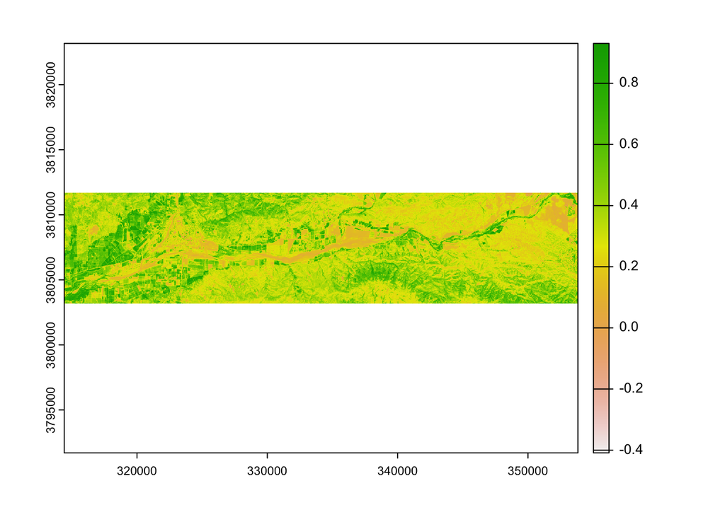

```r
ndvi_20180612 <- lapp(landsat_20180612[[c(4,3)]], fun = ndvi_fun)
plot(ndvi_20180612)
```

```r
ndvi_20180815 <- lapp(landsat_20180815[[c(4, 3)]], fun = ndvi_fun)
ndvi_20181018 <- lapp(landsat_20181018[[c(4, 3)]], fun = ndvi_fun)
ndvi_20181103 <- lapp(landsat_20181103[[c(4, 3)]], fun = ndvi_fun)
ndvi_20190122 <- lapp(landsat_20190122[[c(4, 3)]], fun = ndvi_fun)
ndvi_20190223 <- lapp(landsat_20190223[[c(4, 3)]], fun = ndvi_fun)
ndvi_20190412 <- lapp(landsat_20190412[[c(4, 3)]], fun = ndvi_fun)
ndvi_20190701 <- lapp(landsat_20190701[[c(4, 3)]], fun = ndvi_fun)
```

#### combine NDVI layers

Now we can combine the NDVI layers we created into a single raster stack.

```r
#can use the c function to stack all the rasters
all_ndvi <- c(ndvi_20180612,
              ndvi_20180815,
              ndvi_20181018,
              ndvi_20181103,
              ndvi_20190122,
              ndvi_20190223,
              ndvi_20190412,
              ndvi_20190701)
```

Let’s update the names of each layer to match the date of each image.

```r
names(all_ndvi) <- c("2018-06-12",
                     "2018-08-15",
                     "2018-10-18",
                     "2018-11-03",
                     "2019-01-22",
                     "2019-02-23",
                     "2019-04-12",
                     "2019-07-01")
```

#### read in study sites

```r
#reading in an sf_object that has 5 polygons for vegetation types
sites <- st_read(here("data", "study_sites.shp"))
```

#### extract NDVI at study sites

Here we find the average NDVI within each study site. The output of extract is a data frame with rows that match the study site dataset, so we bind the results to the original dataset.

```r
#taking the mean of all the sites
sites_ndvi <- terra::extract(all_ndvi, sites, fun = "mean")

#Combine R Objects by Rows or Columns
sites_annotated <- cbind(sites, sites_ndvi)
```

#### clean results

We’re done! Except our data is very untidy… Let’s tidy it up!

- covert to data frame
- turn from wide to long format
- turn layer names into date format

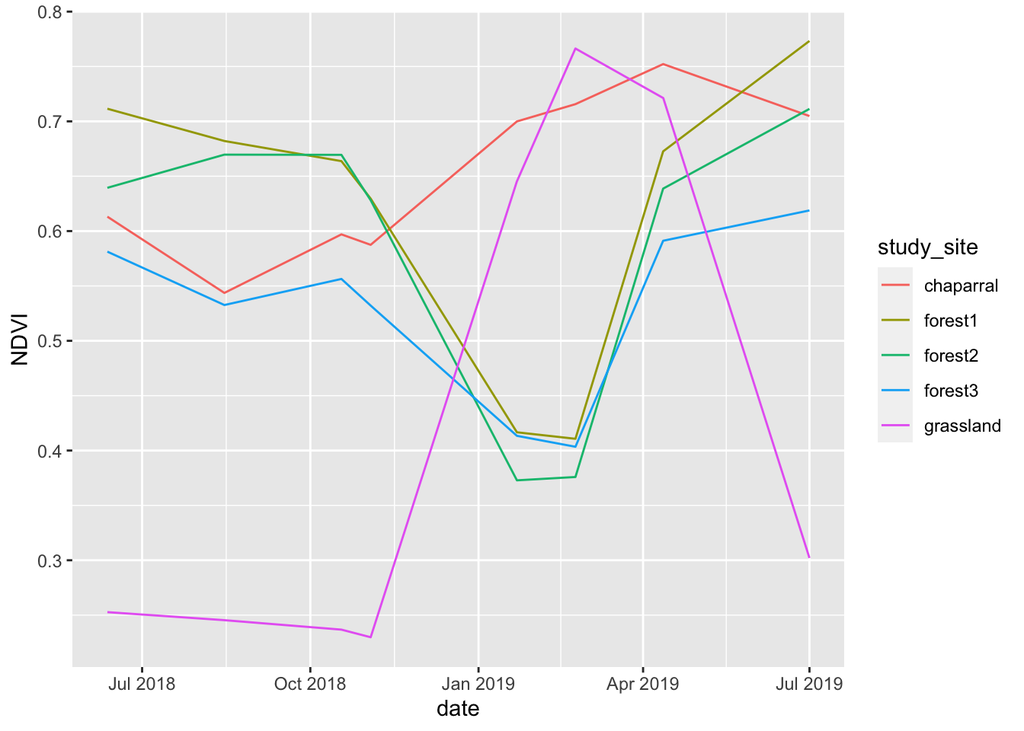

```r
#pivot longer taking data into a long format (things that were columns are now rows)
#renaming the value as NDVI
#string subsetting to get the date out of it --> mutating and then pulling out the year as chatracters 2-5
#the date is the last two characters, this will get us columns from year month day
#then uniting these characters back to a string, and transition this back to a date using libridate

sites_clean <- sites_annotated %>%
  st_drop_geometry() %>%
  select(-ID) %>%
  pivot_longer(!study_site) %>%
  rename("NDVI" = value) %>%
  mutate("year" = str_sub(name, 2, 5),
         "month" = str_sub(name, 7, 8),
         "day" = str_sub(name, -2, -1)) %>%
  unite("date", 4:6, sep = "-") %>%
  mutate("date" = lubridate::as_date(date))
ggplot(sites_clean,
       aes(x = date, y = NDVI, group = study_site, col = study_site)) +
  geom_line()
```

#### plot results

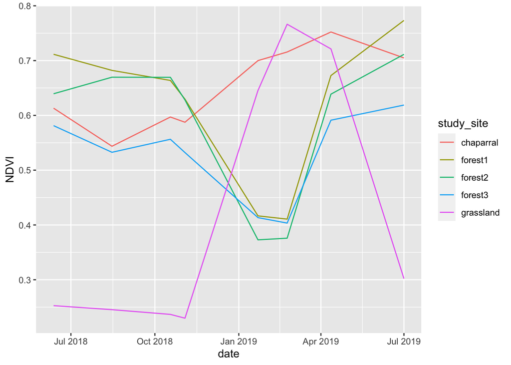

```r
ggplot(sites_clean, aes(x=date, y=NDVI, group = study_site, col = study_site)) + #group by study site and color by study site
    geom_line()
```